# Lab 5: Log-Pearson Type III Analysis

## Introduction

Water managers, hydrologists, and engineers are responsible for making decisions that not only impact people today, but future generations to come. These decisions could include how large to design a culvert for a stream, what legislature should be implemented regarding water use, how to properly plan for population growth for a city based on available water resources, and so on. These decisions are difficult to make, especially when the decisions impacting the future must be made according to the available data of today. To help in making these decisions, hydrologic models have been created to predict the size of hydrologic events, flooding, and to project the status of water budgets. The purpose of this lab is to introduce a probability density model commonly known as the **Log-Pearson Type III distribution** model. This lab will walk through the steps of how to model National Water Census Data Portal (NWC-DP) data using both Microsoft Excel and the Lp3 function found in the NWCEd package in R.

## Important Questions to Ask Yourself

1. What information is contained in a time series plot?
2. How do I interpret the quality of a dataset using a box plot?
3. Who is the intended audience I am trying to communicate information with?

## Useful Terms and Acronyms

| Term | Defintion |
| --- | --- |
| Time Series | A series of values obtained at successive times |
| NWIS | National Water Information System |
| Area Weighted Mean | The sum of area-weighted values divided by the total area |
| Water Balance | A method used to account for water flowing in and out of a system |
| Double-Mass Curve | A graphical method used to study consistency and trends in data |

## Exercise 1

#### Step 1

In this exercise we will learn how to download a .csv file containing precipitation time series data from the National Water Cenus Data-Portal (NWC-DP) and generate a Log-Pearson Type III distribution model for the selected data. For information regarding the theory behind the Log-Pearson Type III distribution model, please read information put out by the [USGS](http://water.usgs.gov/osw/bulletin17b/dl_flow.pdf), the [University of Western Ontario](http://ir.lib.uwo.ca/cgi/viewcontent.cgi?article=1039&context=wrrr), and the [Water Resources Research](http://onlinelibrary.wiley.com/doi/10.1029/WR011i005p00681/abstract) journal.  
To begin, log on to the NWC-DP using the following URL: http://cida.usgs.gov/nwc/. The home page is shown in **Figure 1** below. Click on the tab titled, “Water Budget” in the Menu ribbon on the left of the page or anywhere in the large Water Budget icon to access the Water Budget tool. For more instruction on how to navigate through the NWC-DP and its features, please review **Lab 1** and **Lab 2**.

[figure not shown]

**Figure 1: The NWC-DP homepage.**

After clicking on the Water Budget icon, a new screen will load which displays an interactive map. For this exercise we want to download data associated with the HUC that encompasses Orchard Mesa, Colorado. This HUC is located just south of Grand Junction, Colorado. In the search bar, type “**Grand Junction**” and click on the first suggestion that appears under the search bar as shown in Figure 2 below.

[figure not shown]

**Figure 2: Grand Junction search.**

The map will zoom in to the general region where we can more easily see the HUC we want to select. Under the **`HUC Layer`** dropdown box, select the **12 Digit** layer (see Figure 3 and Figure 4 below). Select the HUC that encompasses Orchard Mesa, Colorado as indicated by the red arrow in Figure 4.

[figure not shown]

**Figure 3: The Grand Junction, Colorado region.**

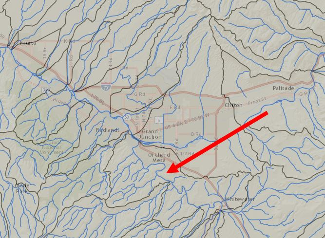

**Figure 4: A 12 Digit HUC layer displayed over Grand Junction, CO.**

Once the new page has loaded, verify that the HUC you selected is the intended HUC you wanted to select. Next, click on the **`Download Precipitation`** button to download a .csv file of the precipitationd data associated with the HUC as shown in Figure 5 below.

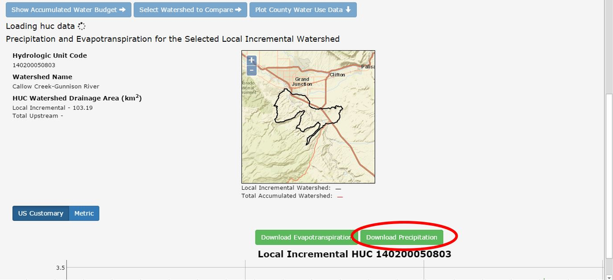

**Figure 5: Download precipitation dataset associated with HUC # 140200050803.**

#### Step 2

Once the file has been downloaded, open it in Microsoft Excel. *Please note that while these steps are to be carried out in Microsoft Excel, similar open source software such as Google Sheets can run the steps with slight adjustments.* Once the file has been downloaded and upen in Excel, the spreadsheet should look similar to that displayed in Figure 6 below.

[figure not shown]

**Figure 6: Opened csv file of precipitation data.**

The first thing we need to do is prepare the spreadsheet for the analysis. We are needing to compile and separate the data based on their respective **water years**. To do this, add a column in between column A and column B. This can be done simply by selecting cell **B6**. Then while holding down the **`control`** and **`shift`** buttons, press the **`down arrow`** key. Once the cells are selected, right click and select **insert** with the **`Shift cells right`** option selected. Click **`OK`**. The column of area weighted mean precipitation values shifts to the right.

[figure not shown]

**Figure 7: Opening the Format Cells window.**

Next, select the empty cell **B6**. Select all the empty cells in between the given dates and data values using the same steps given previously. When all the empty cells have been selected, right click and select **`Format Cells`**. A popup window appears as shown in Figure 7. With the **Number** tab selected, click on **General** in the **Category** box. Doing this will allow us to use a custom formula to convert the dates in column A to water year dates in the empty column B.  
Now that the empty column B has been prepared, we are ready to convert the dates listed in column A into water years. In the empty cell **B6**, enter the following statement:

$$=IF(MONTH(A6)<=9,YEAR(A6),1+YEAR(A6))$$

This statement checks the month of the year in the A column to see if it is in the current water year. If it is, the year is extracted from the cell in column A and inserted into the emtpy adjacent cell in column B. If the month is greater than 9, then 1 is added to the current year to match the correct water year date. Once the formula has been entered into **B6**, double click in the bottom-right corner of the cell to populate the proceeding cells in column B.

Scroll down column B to verify that the year is updating every October. Once the water years have been assigned correctly to the corresponding precipitation values, we are ready to sort our data.

#### Step 3

We are now ready to begin the analysis. As a check, make sure your spreadsheet looks like the one depicted in Figure 8 below. Please note the addition of the **“WtrYr”** table header. Make sure there are no empty columns in between the water year column and the precipitation value column.

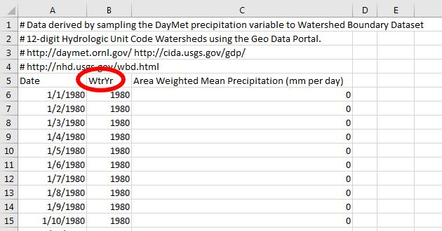

**Figure 8: Spreadsheet formatting check.**

We will now begin using a pivot table in excel to help us quickly run the Log-Pearson Type III distribution for our data. The methods shown in this lab correspond to Microst Excel 2016. These steps can also be performed in previous versions. In your spreadsheet, select the **WtrYr** and **Area Weighted Mean Precipitation** columns including the headers as shown in Figure 9. Under the **`Insert`** tab, click on **PivotTable** button in the upper left-hand corner of the screen. A **Create PivotTable** popup window will then display on the screen. Select **New Worksheet**. Doing this will open the pivot table in a new sheet.

[figure not shown]

**Figure 9: Creating the pivot table.**

After clicking **`OK`** a new sheet will open up as shown in Figure 10. On the right of sheet is the **PivotTable Fields** ribbon. Clicking anywhere in the sheet outside of the **PivotTable** box will hide the pivot table ribbon. clicking anywhere inside the PivotTable box will show the ribbon again.

[figure not shown]

**Figure 10: New pivot table.**

In the PivotTable Fields ribbon, hover the cursor over the **`WtrYr`** words. Click on the **WtrYr** and drag it into the **ROWS** box below. If done successfully, the **`WtrYr`** box will update with a check mark. A column will appear in the sheet with the rows in the column populated with the water years we obtained previously. Hover the cursor over the **`Area Weighted Mean Precipitation`** words under the **`WtrYr`** box. Click and drag it into the **VALUES** box in the lower right-hand corner of the screen. The corresponding box will update with a check mark as before, and a new column is added to the sheet containing all the precipitation values.

[figure not shown]

**Figure 11: Populating the pivot table.**

In the **VALUES** box, click on the **`Count of Area`** drop down menu. Click on the **Value Field Settings** option. A **Value Field Settings** popup window is displayed as shown in Figure 12. Select the **Max** option under the **`Summarize Values By`** tab. Then click **`OK`**.

[figure not shown]

**Figure 12: Finding the max values for each water year.**